# Cbind Result

### Cohort Description

| Table 1. cohort Description |  |
| --- | --- |
|  | cohort |
|  | (Mean ± SD) |
| Number of subjects (n) | 47 |
| Sex (% male) | 48% |
| Age (y) | 30.48±6.67 |
| Weight (kg) | 67.84±12.84 |
| BMI (kg/m2) | 24.7±3.42 |

### Figure

#### Figure 1

[figure not shown]

**Figure 1 Study Design**. The figure presents details of study recruitment and allocation of participants to LCRDI. Criterions for volunteers and completion numbers are also outlined.

#### Figure 2

**Figure 2 Low Calorie Restricted Dietary Intervention alters BMI and circulating amino acids**. A-B, showing BMI and circulating amino acids significantly changed. Two-tailed Paired Wilcoxon rank-sum test, *p<0.05, **p<0.01, ***p<0.001, ****p<0.0001.

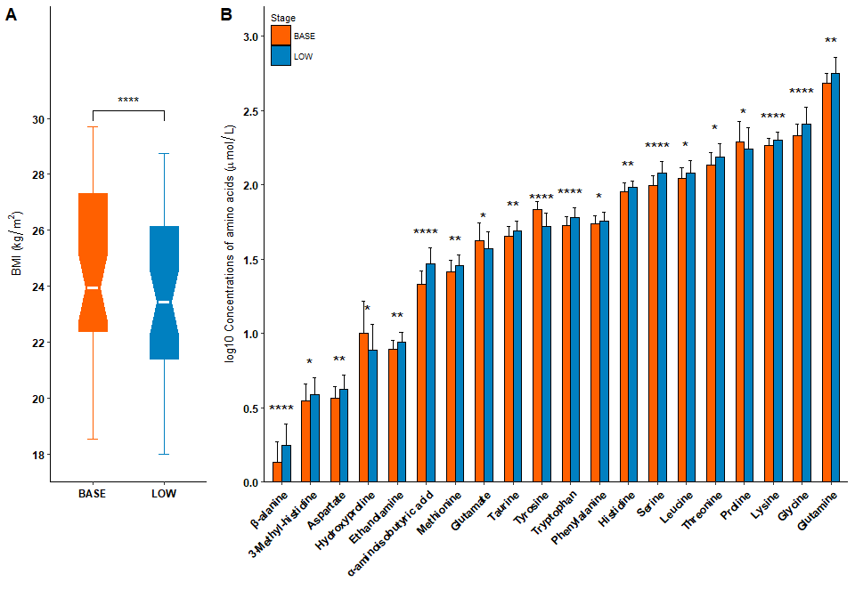

#### Conclusion

- Calorie Restricted diet led to BMI loss.
- Calorie Restricted diet caused that 16 of 20 circulating amino acids increased and 4 of 20 amino acids including Hydroxyproline,Glutamate,Tyrosine,Proline decreased.

#### Figure 3

**Figure 3 Gut microbiota species Composition alters during the study**. A, boxplot shows significant difference Species by Low Calorie Restricted Dietary Intervention. Two-tailed Paired Wilcoxon rank-sum test was used, *p<0.05, **p<0.01. B, Heatmap showing changes in the abundance of significant species after LCRD and Washout (only occurrence > 0.2 are shown), LOW: Low as compared to BASE; WASH: WASH as compared to LOW. Two-tailed Paired Wilcoxon rank-sum test was used, *p<0.05, +p<0.01, #p<0.001. C-D, the statistical significance (y axis) and log2fold-change (x axis) of species between two stages. E, Spearman correlation between microbial changes observed at LOW as compared to BASE; WASH as compared to LOW.

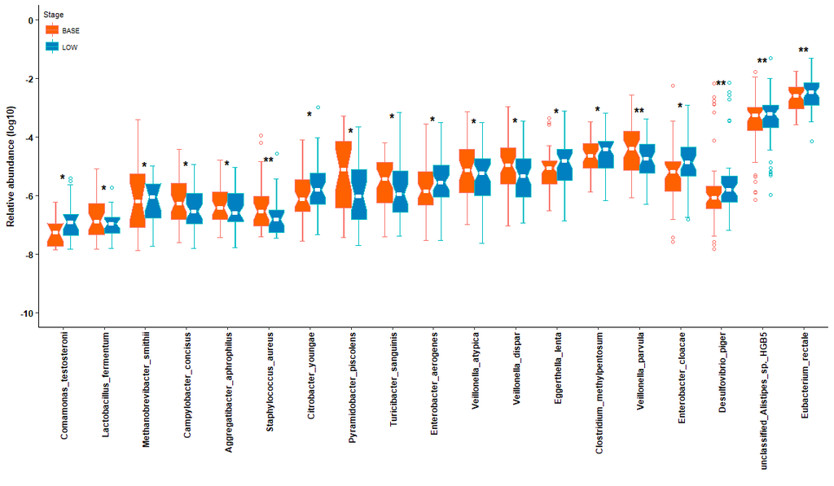

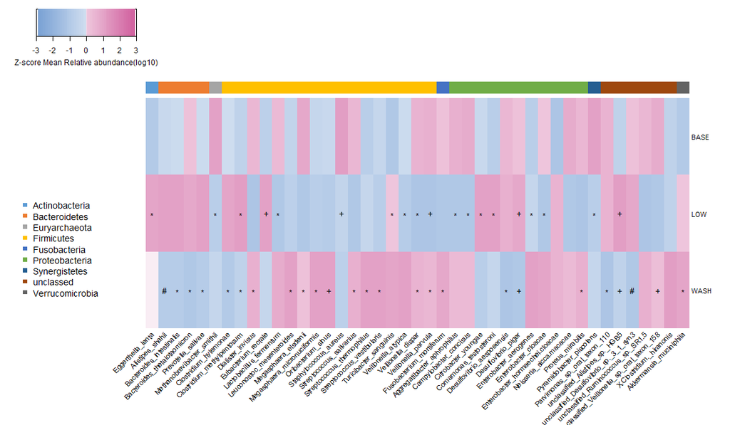

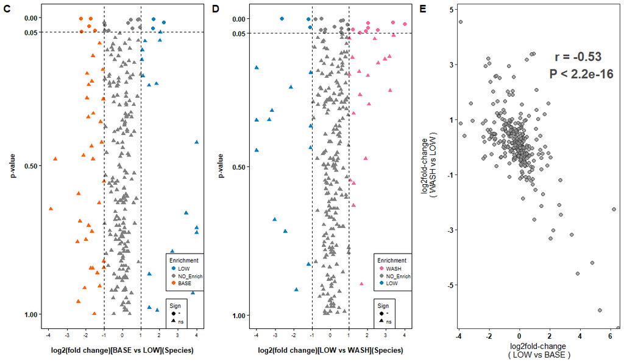